# CAP5 Clustering

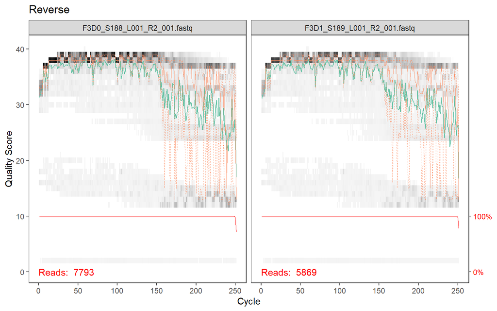

```r
plotQualityProfile(fnRs[1:2]) + ggtitle("Reverse")
```

Genere gráficos similares para cuatro conjuntos seleccionados al azar de lecturas directas e inversas. Compare las cualidades de lectura directa e inversa; ¿que notaste?

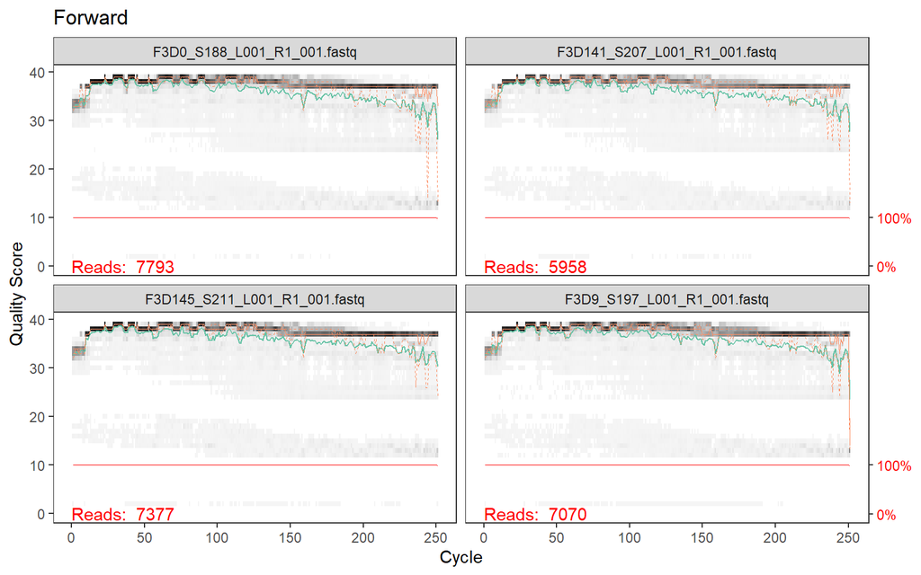

```r
ii = sample(length(fnFs), 4)
plotQualityProfile(fnFs[ii]) + ggtitle("Forward")
```

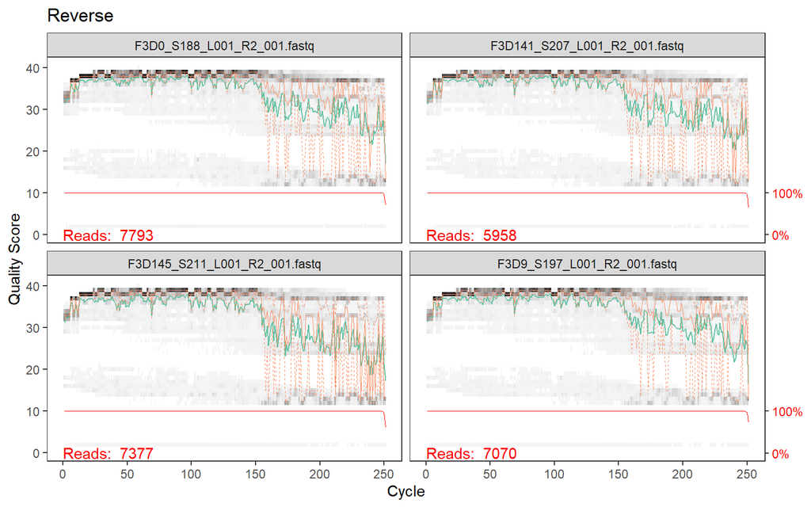

```r
plotQualityProfile(fnRs[ii]) + ggtitle("Reverse")
```

Aquí, las lecturas directas mantienen una alta calidad en todo momento, mientras que la calidad de las lecturas inversas cae significativamente alrededor de la posición 160. Por lo tanto, truncamos las lecturas directas en la posición 240 y recortamos los primeros 10 nucleótidos ya que estas posiciones son de menor calidad. Las lecturas inversas se recortan en la posición 160. Combine estos parámetros de recorte con los parámetros de filtrado estándar y recuerde imponer un máximo de 2 errores esperados por lectura.

```r
out = filterAndTrim(fnFs, filtFs, fnRs, filtRs, truncLen=c(240,160),
        maxN=0, maxEE=2, truncQ=2, rm.phix=TRUE,  trimLeft=10,
        compress=TRUE, multithread=TRUE) # On Windows set multithread=FALSE
head(out)
```

```
##                               reads.in reads.out
## F3D0_S188_L001_R1_001.fastq       7793      7139
## F3D1_S189_L001_R1_001.fastq       5869      5314
## F3D141_S207_L001_R1_001.fastq     5958      5478
## F3D142_S208_L001_R1_001.fastq     3183      2926
## F3D143_S209_L001_R1_001.fastq     3178      2955
## F3D144_S210_L001_R1_001.fastq     4827      4323
```

Los datos de la secuencia se importaron a R desde fastq archivos fastq para cada muestra) y se desreplicaron simultáneamente para eliminar la redundancia.

```r
derepFs = derepFastq(filtFs, verbose = FALSE)
derepRs = derepFastq(filtRs, verbose = FALSE)
names(derepFs) = sampleNames
names(derepRs) = sampleNames
```